# Project 2 - Association Rules

Jón Þorsteinsson - jth56@hi.is

Kristófer Már Gíslason - kmg14@hi.is

### 1. Objectives

The data set we are working with predicts if a patient is likely or not to have a chronic kidney disease based on various attributes that are all based on different medical tests. The objective of the project is to use association rule mining to identify patterns between different attributes of the data set. If the patterns we find are good enough it might be possible for doctors to identify certain patterns between symptoms and maybe skip certain tests on patients which could then hopefully help them when deciding on which tests could be more usefull than others when diagnosing a patient. The rule set could also be used to fill in some missing data in the data set which could then be used to get a better classification for the data.

### 2. Data set description

The data set has 400 different instances that each contain 24 different attributes and one class attribute that tells if the patient has the disease or not. The attributes are:

| Nr. | Name | Type | Description |
| --- | --- | --- | --- |
| 1. | Age | numerical | Age in years. |
| 2. | Blood Pressure | numerical | bp in mm/Hg. |
| 3. | Specific Gravity | nominal | sg - (1.005,1.010,1.015,1.020,1.025). |
| 4. | Albumin | nominal | al - (0,1,2,3,4,5). |
| 5. | Sugar | nominal | su - (0,1,2,3,4,5). |
| 6. | Red Blood Cells | nominal | rbc - (normal,abnormal) |
| 7. | Pus Cell | nominal | pc - (normal,abnormal) |
| 8. | Pus Cell clumps | nominal | pcc - (present,notpresent) |
| 9. | Bacteria | nominal | ba - (present,notpresent) |
| 10. | Blood Glucose Random | numerical | bgr in mgs/dl |
| 11. | Blood Urea | numerical | bu in mgs/dl |
| 12. | Serum Creatinine | numerical | sc in mgs/dl |
| 13. | Sodium | numerical | sod in mEq/L |
| 14. | Potassium | numerical | pot in mEq/L |
| 15. | Hemoglobin | numerical | hemo in gms |
| 16. | Packed Cell Volume | numerical | pcv |
| 17. | White Blood Cell Count | numerical | wc in cells/cumm |
| 18. | Red Blood Cell Count | numerical | rc in millions/cmm |
| 19. | Hypertension | nominal | htn - (yes,no) |
| 20. | Diabetes Mellitus | nominal | dm - (yes,no) |
| 21. | Coronary Artery Disease | nominal | cad - (yes,no) |
| 22. | Appetite | nominal | appet - (good,poor) |
| 23. | Pedal Edema | nominal | pe - (yes,no) |
| 24. | Anemia | nominal | ane - (yes,no) |
| 25. | Class | nominal | class - (ckd,notckd) |

# Preprocessing

```r
# read in .arff file
chronic <- read.arff("chronic_kidney_disease_full.arff")

# discretize using equal frequency
chronic_freq <- discretizeDF(chronic, methods = list(
  age = list(method = "frequency", breaks = 10 ),
  bp  = list(method = "frequency", breaks = 3 ),
  bgr = list(method = "frequency", breaks = 10 ),
  bu  = list(method = "frequency", breaks = 10 ),
  sc  = list(method = "frequency", breaks = 10 ),
  sod = list(method = "frequency", breaks = 10 ),
  pot = list(method = "frequency", breaks = 10 ),
  hemo= list(method = "frequency", breaks = 10 ),
  pcv = list(method = "frequency", breaks = 10 ),
  wbcc= list(method = "frequency", breaks = 10 ),
  rbcc= list(method = "frequency", breaks = 10 )
  ))

# discretize using equal interval
chronic_interval <- discretizeDF(chronic, methods = list(
  age = list(method = "interval", breaks = 10 ),
  bp  = list(method = "interval", breaks = 10 ),
  bgr = list(method = "interval", breaks = 10 ),
  bu  = list(method = "interval", breaks = 10 ),
  sc  = list(method = "interval", breaks = 10 ),
  sod = list(method = "interval", breaks = 10 ),
  pot = list(method = "interval", breaks = 10 ),
  hemo= list(method = "interval", breaks = 10 ),
  pcv = list(method = "interval", breaks = 10 ),
  wbcc= list(method = "interval", breaks = 10 ),
  rbcc= list(method = "interval", breaks = 10 )
  ))

# Removing the class attribute.
chronic_freq$class <- NULL
chronic_interval$class <- NULL
```

### 3. Rule mining process

```r
# Running the apriori algorithm.
freq.rules <- apriori(chronic_freq, parameter=list(support = 0.1,
              confidence = 0.9, minlen=2, maxlen=4))

interval.rules <- apriori(chronic_interval, parameter=list(support = 0.1,
                  confidence = 0.9, minlen=2, maxlen=4))
```

```r
sum.freq <- summary(freq.rules)
sum.interval <- summary(interval.rules)

# Information about the equal frequency rule set
sum.freq@quality
```

```
##     support         confidence          lift            count
##  Min.   :0.1000   Min.   :0.9000   Min.   :0.9626   Min.   : 40.0
##  1st Qu.:0.1600   1st Qu.:0.9351   1st Qu.:1.0695   1st Qu.: 64.0
##  Median :0.2000   Median :0.9583   Median :1.1415   Median : 80.0
##  Mean   :0.2718   Mean   :0.9568   Mean   :1.2070   Mean   :108.7
##  3rd Qu.:0.4075   3rd Qu.:0.9784   3rd Qu.:1.2989   3rd Qu.:163.0
##  Max.   :0.8600   Max.   :1.0000   Max.   :1.9813   Max.   :344.0
```

```r
# Size of the equal frequancy rule set
sum.freq@lengths
```

```
## sizes
##    2    3    4
##   94  880 3892
```

```r
# Information about the equal interval rule set
sum.interval@quality
```

```
##     support         confidence          lift            count
##  Min.   :0.1000   Min.   :0.9000   Min.   :0.9626   Min.   : 40.00
##  1st Qu.:0.1200   1st Qu.:0.9375   1st Qu.:1.0769   1st Qu.: 48.00
##  Median :0.1450   Median :0.9605   Median :1.1525   Median : 58.00
##  Mean   :0.1991   Mean   :0.9593   Mean   :1.2199   Mean   : 79.63
##  3rd Qu.:0.2125   3rd Qu.:0.9811   3rd Qu.:1.2945   3rd Qu.: 85.00
##  Max.   :0.8600   Max.   :1.0000   Max.   :2.0101   Max.   :344.00
```

```r
# Size of the equal interval rule set
sum.interval@lengths
```

```
## sizes
##     2     3     4
##   213  3230 21946
```

```r
# Scatter plot for the equal frequency rule set
plot(freq.rules)
```

```
## To reduce overplotting, jitter is added! Use jitter = 0 to prevent jitter.
```

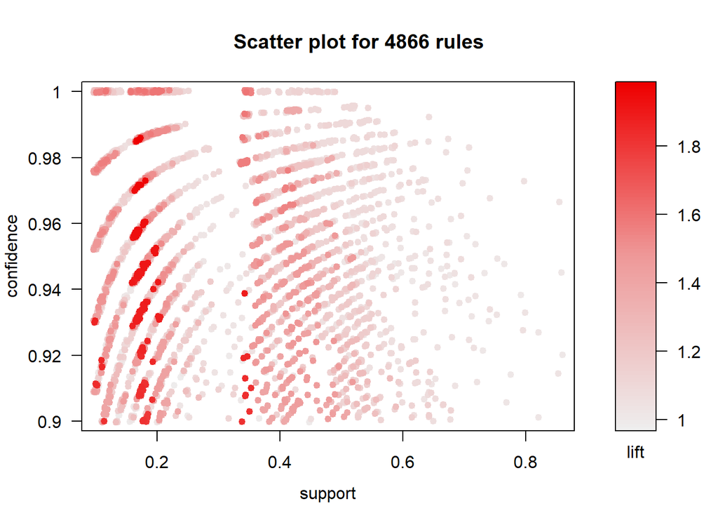

```
## To reduce overplotting, jitter is added! Use jitter = 0 to prevent jitter.
```

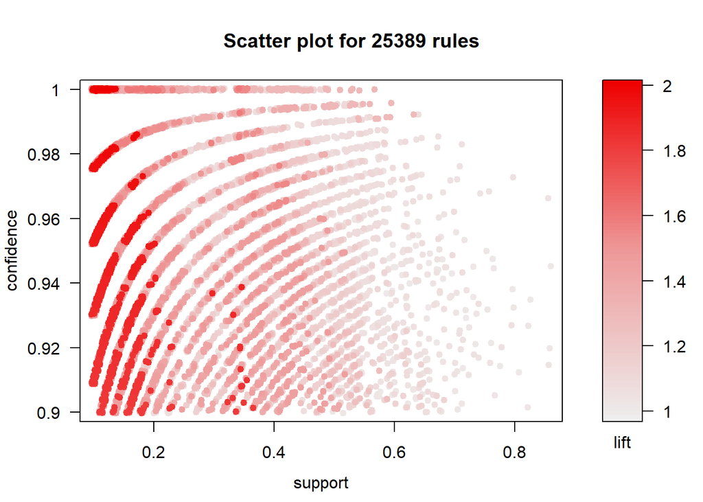

```r
# Scatter plot for the equal interval rule set
plot(interval.rules)
```

The mean for confidence is pretty similar in both cases the interval discretization has a little bit higher average lift. The biggest difference is between support but that is probably because the rule set which we get with the interval discretization is much bigger than the other one and therefore probably has many low supported rules. Ploting the results we could see that the equal frequency discretization gave us fewer rules and fewer rules with high lift however the equal interval discretization gave us way too many rules but more rules with higher lift.

Looking at our data we saw that some of our attributes had a wide range of values but the most common values were all at the same small interval. For that reason we decided to use a change our discretization and use equal frequency for those attributes and equal intervals for the other ones. With that approach we got higher average confidence and lift and a more manageble rule set than by using only equal intervals. Looking at the plot we can also see that we get rid of alot of uninteresting rules from our equal interval rule set but get more rules with high lift than in our equal frequency rule set. It is also interesting that we have don’t seem to have any rules between about 0.25 to 0.32 in support and only a few over 0.32 support with high lift.

[figure not shown]

```
## To reduce overplotting, jitter is added! Use jitter = 0 to prevent jitter.
```

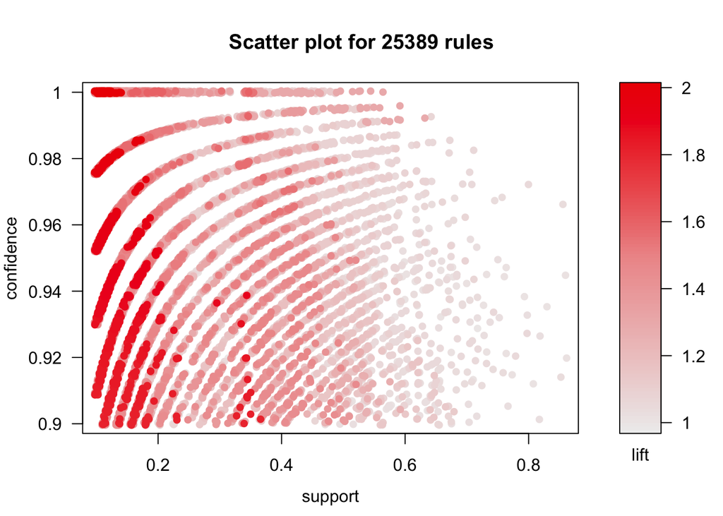

```r
# Scatter plot for the equal interval rule set
plot(interval.rules)
```

The mean for confidence is pretty similar in both cases the interval discretization has a little bit higher average lift. The biggest difference is between support but that is probably because the rule set which we get with the interval discretization is much bigger than the other one and therefor probably has many low supported rules. Ploting the results we could see that the equal frequency discretization gave us fewer rules and fewer rules with high lift and the equal interval discretization gave us way to many rules but more rules with higher lift.

Looking at our data we saw that some of our attributes had a wide range of values but the most common values were all at the same small interval. For that reason we decided to use a change our discretization and use equal frequency for those attributes and equal intervals for the other ones. With that approach we got higher average confidence and lift and a more manageble rule set than by using only equal intervals. Looking at the plot we can also see that we get rid of alot uninteresting rules from our equal interval rule set but get more rules with high lift than in our equal frequency rule set. It is also interesting that we have don’t seem to have any rules between about 0.25 to 0.32 in support and only a few over 0.32 support with high lift.

```r
# Discretizising with a mixed method
chronicDisc <- discretizeDF(chronic, methods = list(
  age = list(method = "interval", breaks = 10 ),
  bp  = list(method = "interval", breaks = 10 ),
  bgr = list(method = "frequency", breaks = 10 ),
  bu  = list(method = "frequency", breaks = 10 ),
  sc  = list(method = "frequency", breaks = 10 ),
  sod = list(method = "frequency", breaks = 10 ),
  pot = list(method = "frequency", breaks = 10 ),
  hemo= list(method = "interval", breaks = 10 ),
  pcv = list(method = "interval", breaks = 10 ),
  wbcc= list(method = "frequency", breaks = 10 ),
  rbcc= list(method = "interval", breaks = 10 )
  ))

chronicDisc$class <- NULL

# Running the apriori algorithm on our new data set
chronic.rules <- apriori(chronicDisc, parameter=list(support = 0.1,
              confidence = 0.9, minlen=2, maxlen=4))
```

```r
sum.chronic <- summary(chronic.rules)
# Statistics for the new rule set
sum.chronic@quality
```

```
##     support         confidence          lift            count
##  Min.   :0.1000   Min.   :0.9000   Min.   :0.9626   Min.   : 40.00
##  1st Qu.:0.1175   1st Qu.:0.9444   1st Qu.:1.0867   1st Qu.: 47.00
##  Median :0.1400   Median :0.9672   Median :1.1799   Median : 56.00
##  Mean   :0.1994   Mean   :0.9644   Mean   :1.2572   Mean   : 79.76
##  3rd Qu.:0.1988   3rd Qu.:0.9867   3rd Qu.:1.3958   3rd Qu.: 79.50
##  Max.   :0.8600   Max.   :1.0000   Max.   :2.0101   Max.   :344.00
```

```r
# Size of the new rule set
sum.chronic@lengths
```

```
## sizes
##    2    3    4
##  160 1643 7764
```

```r
# Scatter plot for our new rule set.
plot(chronic.rules)
```

```
## To reduce overplotting, jitter is added! Use jitter = 0 to prevent jitter.
```

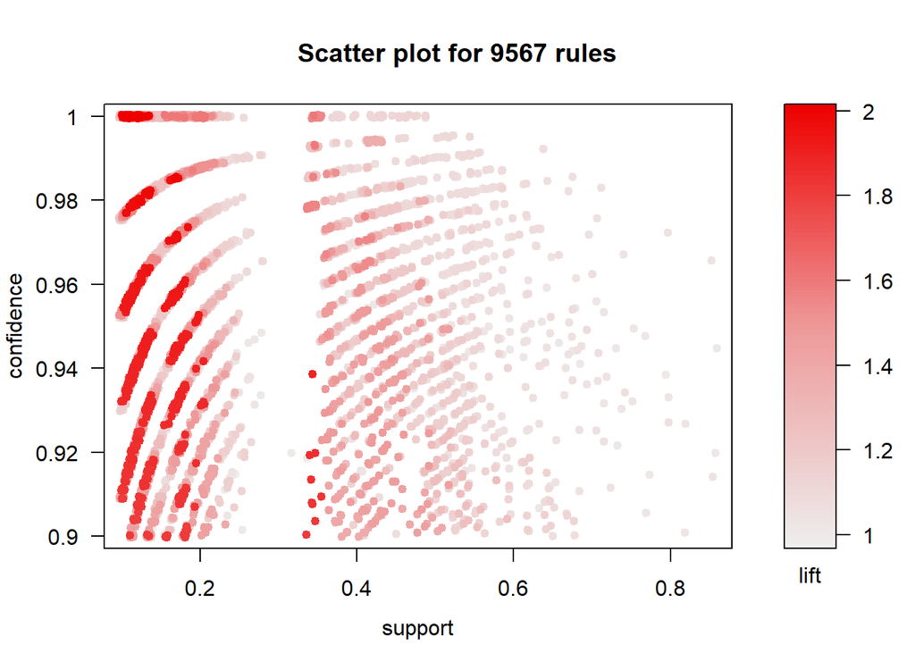

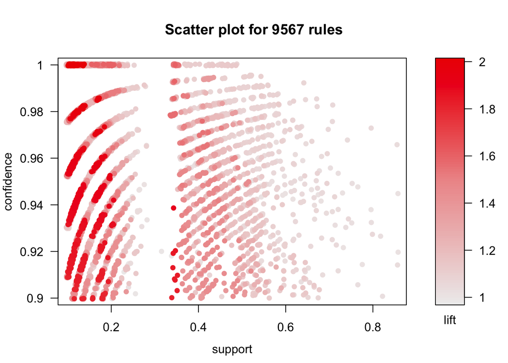

```r
# Getting the 20 rules with the highest lift
inspect(head(chronic.rules, n = 20, by ="lift"))
```

```
##      lhs                                          rhs    support
## [1]  {rbc=normal,pcv=[45,49.5)}                => {al=0} 0.1125
## [2]  {rbc=normal,rbcc=[5.05,5.64)}             => {al=0} 0.1075
## [3]  {rbc=normal,hemo=[13.4,14.9)}             => {al=0} 0.1225
## [4]  {rbc=normal,pcv=[45,49.5),htn=no}         => {al=0} 0.1100
## [5]  {rbc=normal,pcv=[45,49.5),dm=no}          => {al=0} 0.1100
## [6]  {rbc=normal,pc=normal,pcv=[45,49.5)}      => {al=0} 0.1125
## [7]  {su=0,rbc=normal,pcv=[45,49.5)}           => {al=0} 0.1125
## [8]  {rbc=normal,pcv=[45,49.5),appet=good}     => {al=0} 0.1125
## [9]  {rbc=normal,pcv=[45,49.5),pe=no}          => {al=0} 0.1125
## [10] {rbc=normal,pcv=[45,49.5),ane=no}         => {al=0} 0.1125
## [11] {rbc=normal,pcc=notpresent,pcv=[45,49.5)} => {al=0} 0.1075
## [12] {rbc=normal,pcv=[45,49.5),cad=no}         => {al=0} 0.1100
## [13] {rbc=normal,ba=notpresent,pcv=[45,49.5)}  => {al=0} 0.1075
## [14] {rbc=normal,rbcc=[5.05,5.64),htn=no}      => {al=0} 0.1025
```

[output cut: 27 more lines]

Looking at the highest ranked rules by lift we can see that they all share 2-3 items and they all have *{al=0}* on the right hand side and most of them have *{rbc=normal}* and *{pcv=[45,49.5]}* on the left hand side. This is not very usefull to us but it is likely that we could get equally as good shorter rules by decreasing the maximum length of our rules. By looking at a two-key plot for our rules we can also see that the rules of length 4 seem to be very similar to the rules of length 3.

```r
plot(chronic.rules, method = "two-key plot")
```

```
## To reduce overplotting, jitter is added! Use jitter = 0 to prevent jitter.
```

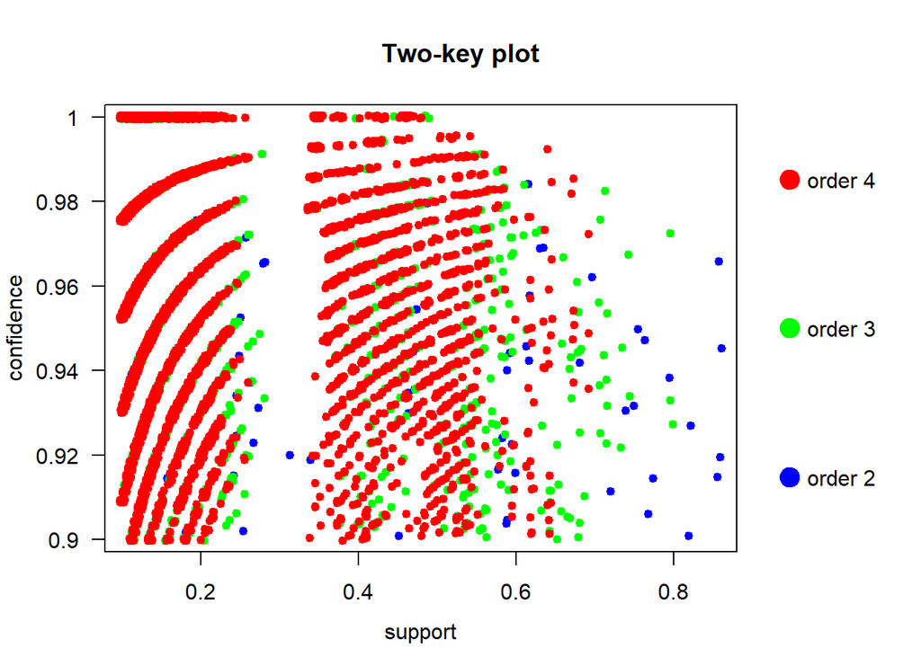

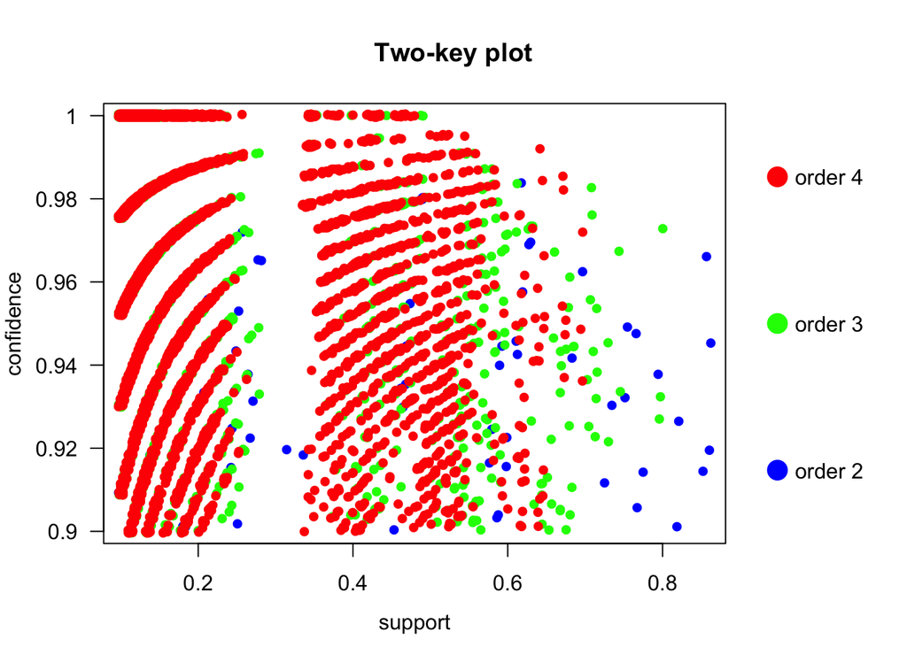

```r
# Running the apriori algorithm again with maxlen=3
chronic.rules <- apriori(chronicDisc, parameter=list(support = 0.1,
              confidence = 0.9, minlen=2, maxlen=3))
```

```r
# Gettting the best lift rules with maxlen=3
inspect(head(chronic.rules, n = 20, by ="lift"))
```

```
##      lhs                              rhs          support confidence
## [1]  {rbc=normal,pcv=[45,49.5)}    => {al=0}       0.1125  1.0000000
## [2]  {rbc=normal,rbcc=[5.05,5.64)} => {al=0}       0.1075  1.0000000
## [3]  {rbc=normal,hemo=[13.4,14.9)} => {al=0}       0.1225  1.0000000
## [4]  {al=0,pcv=[45,49.5)}          => {rbc=normal} 0.1125  1.0000000
## [5]  {hemo=[13.4,14.9),htn=no}     => {al=0}       0.1375  0.9821429
## [6]  {rbc=normal,hemo=[14.9,16.3)} => {al=0}       0.1225  0.9800000
## [7]  {su=0,rbcc=[5.05,5.64)}       => {al=0}       0.1175  0.9791667
## [8]  {pc=normal,rbcc=[5.05,5.64)}  => {al=0}       0.1150  0.9583333
## [9]  {su=0,pcv=[45,49.5)}          => {al=0}       0.1125  0.9574468
## [10] {pcv=[45,49.5),htn=no}        => {al=0}       0.1100  0.9565217
## [11] {rbcc=[5.05,5.64),htn=no}     => {al=0}       0.1100  0.9565217
## [12] {rbcc=[5.05,5.64),dm=no}      => {al=0}       0.1075  0.9555556
## [13] {su=0,hemo=[13.4,14.9)}       => {al=0}       0.1375  0.9482759
## [14] {su=0,pcv=[45,49.5)}          => {rbc=normal} 0.1125  0.9574468
```

[output cut: 27 more lines]

The resulting rules are shorter which is better but they still contain mostly the same items just like the first rule set. Since they all have low support and most of our high lift rules have low support we assume that these attributes have something to do with similar symptoms that are also not that common and might not be that interesting. We decided to increase the support threshold of our algorithm to 0.3 because we suspect that the rules that are over that threshold could be more interesting and give us a more focused view of the data.

The resulting rules are shorter which is better but they still contain mostly the same items just like the first rule set. Since they all have low support and most of our high lift rules have low support we assume that these attributes have something to do with similar symptoms that are also not that common and might not be that interesting. We decide to increase the support threshold of our algorithm to 0.3 because we suspect that the rules over that are over that threshold could be more interesting.

```r
# Running the apriori algorithm again with maxlen=3 and support=0.3
chronic.rules <- apriori(chronicDisc, parameter=list(support = 0.3,
              confidence = 0.9, minlen=2, maxlen=3))
```

```r
# Gettting the best lift rules with maxlen=3 and support=0.3
inspect(head(chronic.rules, n = 20, by ="lift"))
```

```
##      lhs                      rhs         support confidence lift
## [1]  {al=0,rbc=normal}     => {htn=no}    0.3450  0.9787234  1.559719
## [2]  {al=0,rbc=normal}     => {pc=normal} 0.3525  1.0000000  1.544402
## [3]  {al=0,dm=no}          => {htn=no}    0.4200  0.9655172  1.538673
## [4]  {al=0,rbc=normal}     => {dm=no}     0.3450  0.9787234  1.499959
## [5]  {rbc=normal,htn=no}   => {dm=no}     0.3800  0.9620253  1.474368
## [6]  {al=0,dm=no}          => {pc=normal} 0.4150  0.9540230  1.473395
## [7]  {al=0,su=0}           => {pc=normal} 0.4450  0.9468085  1.462253
## [8]  {rbc=normal,dm=no}    => {htn=no}    0.3800  0.9156627  1.459223
## [9]  {al=0,su=0}           => {htn=no}    0.4300  0.9148936  1.457998
## [10] {al=0,pe=no}          => {pc=normal} 0.4500  0.9424084  1.455457
## [11] {su=0,htn=no}         => {dm=no}     0.5175  0.9495413  1.455236
## [12] {al=0,htn=no}         => {dm=no}     0.4200  0.9491525  1.454640
## [13] {al=0,appet=good}     => {pc=normal} 0.4350  0.9405405  1.452572
## [14] {pc=normal,dm=no}     => {htn=no}    0.4600  0.9108911  1.451619
```

[output cut: 27 more lines]

Now we get rules with a little bit lower lift and confidence but both factors are still pretty high and the support is much higher. Most of the rules contain the same parameters which are also the same ones as we got in most of the rules when running the algorithm with a lower support threshold. The same is true if we look at more rules so we decided not to show more than 20 of them.

We get rules with a little bit lower lift and confidence but both factors are still pretty high and the support is much higher. Most of the rules contain the samt parameters which are also the same ones we got in most of the rules when running the algorithm with a lower support threshold. The same is true if we look at more rules so we decided not to show more than 20.

```r
sum.chronic <- summary(chronic.rules)
# Statistics for the new rule set
sum.chronic@quality
```

```
##     support         confidence          lift            count
##  Min.   :0.3150   Min.   :0.9000   Min.   :0.9822   Min.   :126.0
##  1st Qu.:0.4350   1st Qu.:0.9257   1st Qu.:1.0450   1st Qu.:174.0
##  Median :0.5100   Median :0.9452   Median :1.0930   Median :204.0
##  Mean   :0.5221   Mean   :0.9455   Mean   :1.1323   Mean   :208.8
##  3rd Qu.:0.5825   3rd Qu.:0.9674   3rd Qu.:1.1709   3rd Qu.:233.0
##  Max.   :0.8600   Max.   :1.0000   Max.   :1.5597   Max.   :344.0
```

```r
# Size of the new rule set
sum.chronic@lengths
```

```
## sizes
##   2   3
##  43 340
```